# Демонстрация проекта

```python
import pandas as pd
import numpy as np
from warnings import filterwarnings
from ipywidgets import widgets
from tools import * #модуль с функциями, использующимися для работы ноутбука
```

```python
filterwarnings('ignore')
data = pd.read_csv('taxi_trips.csv',index_col=0,parse_dates=[0])
data.head()
```

|  | 1075 | 1076 | 1077 | 1125 | 1126 | 1127 | 1128 | 1129 | 1130 | 1131 | ... | 1630 | 1684 | 1733 | 1734 | 1783 | 2068 | 2069 | 2118 | 2119 | 2168 |
| --- | --- | --- | --- | --- | --- | --- | --- | --- | --- | --- | --- | --- | --- | --- | --- | --- | --- | --- | --- | --- | --- |
| 2015-12-01 00:00:00 | 19.0 | 43.0 | 26.0 | 76.0 | 91.0 | 129.0 | 202.0 | 230.0 | 212.0 | 56.0 | ... | 3.0 | 0.0 | 2.0 | 97.0 | 29.0 | 96.0 | 16.0 | 246.0 | 31.0 | 118.0 |
| 2015-12-01 01:00:00 | 16.0 | 22.0 | 12.0 | 29.0 | 71.0 | 84.0 | 89.0 | 118.0 | 177.0 | 18.0 | ... | 7.0 | 0.0 | 0.0 | 2.0 | 0.0 | 17.0 | 4.0 | 104.0 | 5.0 | 75.0 |
| 2015-12-01 02:00:00 | 8.0 | 19.0 | 3.0 | 9.0 | 21.0 | 42.0 | 76.0 | 99.0 | 180.0 | 14.0 | ... | 5.0 | 0.0 | 0.0 | 0.0 | 0.0 | 4.0 | 1.0 | 28.0 | 0.0 | 0.0 |
| 2015-12-01 03:00:00 | 3.0 | 12.0 | 5.0 | 7.0 | 17.0 | 33.0 | 45.0 | 93.0 | 136.0 | 12.0 | ... | 7.0 | 0.0 | 0.0 | 0.0 | 0.0 | 0.0 | 0.0 | 50.0 | 0.0 | 0.0 |
| 2015-12-01 04:00:00 | 2.0 | 12.0 | 3.0 | 7.0 | 21.0 | 33.0 | 27.0 | 62.0 | 80.0 | 3.0 | ... | 4.0 | 1.0 | 0.0 | 4.0 | 2.0 | 2.0 | 0.0 | 23.0 | 1.0 | 15.0 |

5 rows × 102 columns

По-хорошему, для демонстрации данного проекта нужно создать сайт с интерактивной картой, чтобы все вычсилялось на сервере и карты с графиками отображались на любом компьюетере, даже без питона и уж тем более без библиотек. Однако у меня нет возможности и желания поднимать свой сервер 24/7, так что придется демонстрировать в ноутбуке.

Здесь представлена демонстрация двух видов: **бизнес-демонстрация** - это демонстрация конечного продукта для заказчика. А именно - интерактивная карта, на которой можно выбрать дату и время и увидеть предсказанные значения количества поездок в каждом районе. **Техническая демонстрация** - это скорее для аналитиков со стороны бизнеса, чтобы показать им, что модель работает вполне адекватно и предъявить качество.

## Бизнес-демонстрация

```python
def display_prediction(datetime=pd.to_datetime('2016-05-09 12:00:00')):
    return embed_map(create_map(multiprediction(data,datetime)))
```

**Инструкция**: необходимо выбрать время из представленного списка. На карте будет отображена сетка с цветовым окрасом в зависимости от количества поездок в выбранный час. Точное значение количества поездок можно узнать, нажав на интересующую вас ячейку. *Построение прогнозов может занять некоторое время.*

```python
widgets.interact(display_prediction, datetime=pd.date_range(start='2016-01-01 00:00:00',end='2016-06-30 23:00:00',freq='H'))
```

[interactive chart not shown]

```
<function __main__.display_prediction>
```

## Техническая демонстрация

```python
def plots(area, start=pd.to_datetime('2016-05-01 00:00:00'), stop=pd.to_datetime('2016-05-31 23:00:00')):
    plot_prediction(one_area_prediction(data, area, start, stop))
```

Здесь необходимо выбрать зону, интересующую вас (местоположение зоны можно узнать на карте выше), начало интересующего вас периода и его конец. На графике будут предсталвены ряд реальных значений количества поездок в данный период и ряд предсказаний модели. Также будет представлен график ошибок модели, средняя абсолютная, средняя квадратическая и средняя ошибки за данный период.

```
First plot: real numbers of taxi drives (blue) and predicted (red)
Second plot: errors
```

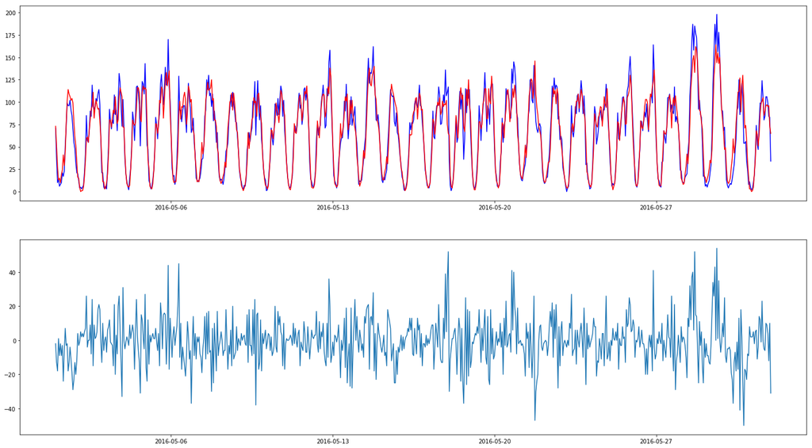

```
MAE:  9.958333333333334
MSE:  185.22177419354838
Mean Error:  -0.09543010752688172
```

```
<function __main__.plots>
```

```python
daterange = pd.date_range(start='2016-01-01 00:00:00',end='2016-06-30 23:00:00',freq='H')
display(widgets.interact(plots, start=daterange,
                 stop=daterange,area=data.columns))
```